# Capstone Project

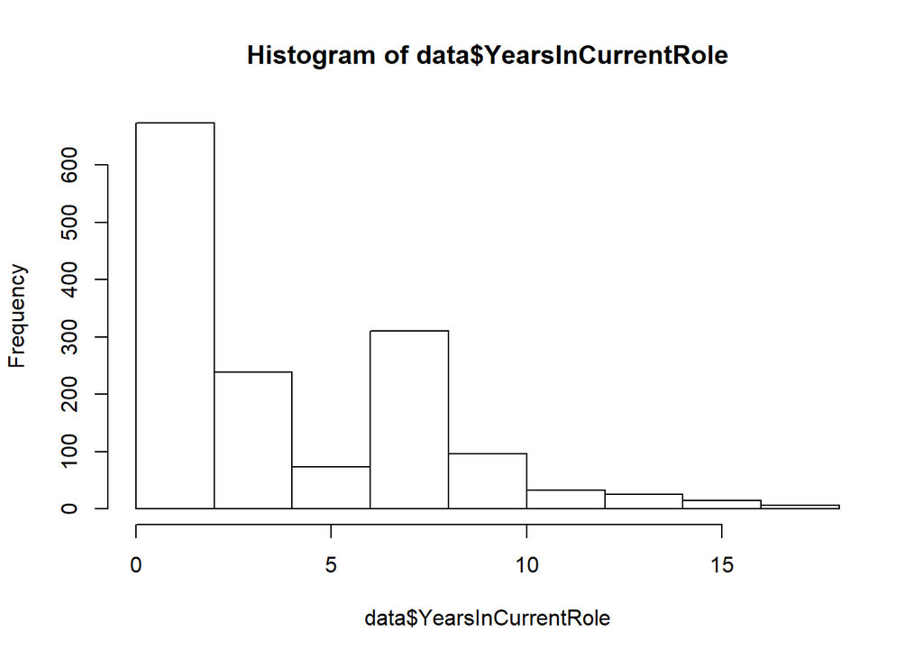

```r
hist(data$YearsInCurrentRole)
```

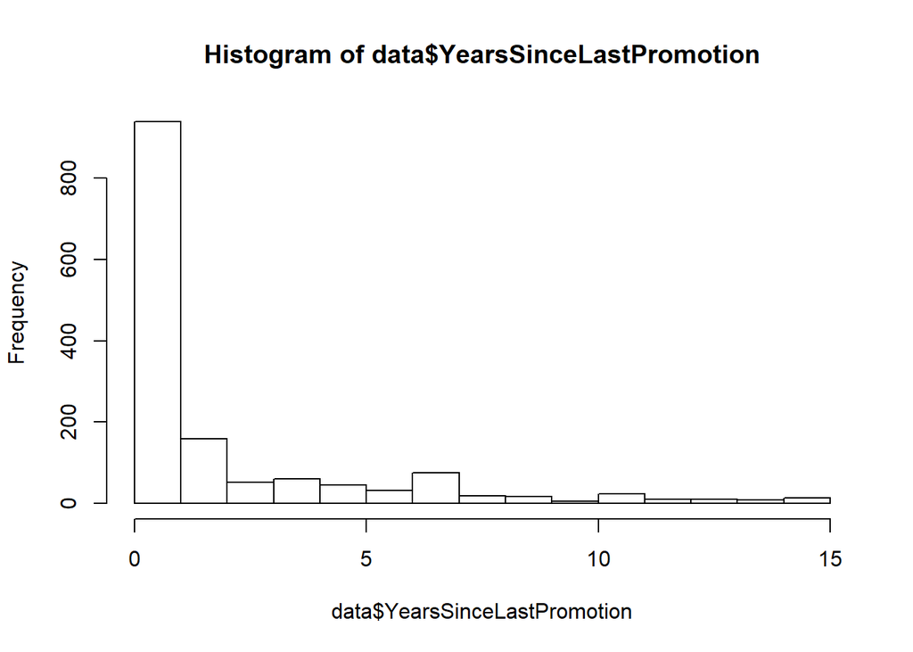

```r
hist(data$YearsSinceLastPromotion)
```

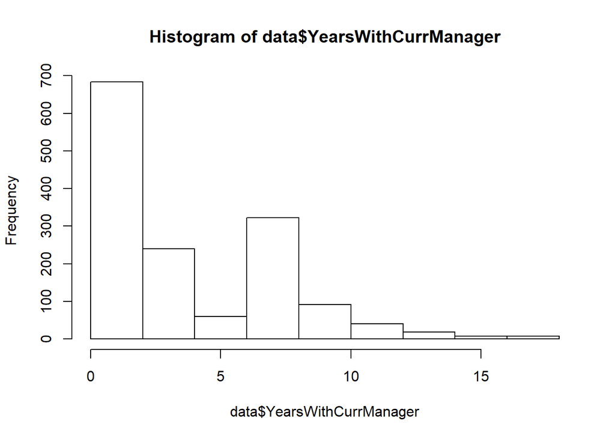

```r
hist(data$YearsWithCurrManager)
```

Results

Dependent variable Attrition - attrition rate is 16%

Independent variables Age - employee are young (mean age is 36 years)

Business Travel - 80% of employees travel rarely or not at all

Daily rate - distribution is flat

Department - 65% of employees work in R&D, 30% in Sales

Distance from home - most employees work < 10km from home

Education - 65% of employees have bachelor degree or better

Education Field - 80% of employees have a technical degree

EmployeeCount - only one value, will be removed

EmployeeNumber- internal number, will be removed

Environment Satisfaction - most employees have a high environment satisfaction

Gender - 60% men, 40% women

Hourly Rate - distribution is flat

Job Involvement - most employees have a high job involvement

Job level - the job level for most employees is fairly low

Job Role - 17% management, 22% sales, technical 60%

Job Satisfaction - most employees have a high job satisfaction

Maritial status - 22% divorced, 46% married, 31% single

Monthly Income - distribution is skewed, most employees have a low monthly income (median = 4900 vs mean = 6500)

Monthly rate - distribution is flat

Num Companies Worked - most employees have only worked for a few companies (median = 2)

Over18 - only one value, will be removed

Overtime - 30% of employees get overtime, 70% do not get overtime

Percent salary Hike - most employees got the average salary

Performance Rating - distribution is skewed, there are only 3 and 4 ratings

Relationship Satisfaction - most employees are satisfied with relationship

StandardHours - only one value, will be removed

Stock Options Levels - 80% of employees get zero or few stock options

Total Working Years - most employees have about 10 years work experience

Training Times - most employees were trained 2 - 3 times in the year

Work Life Balance - most employees are happy with work life balance

Years at Company - 80% of employees have been with the company less than 10 years

Years in Role - most employees have been in their role less than 5 years

Years since promotion - most employees have been promoted within last years

Years with manager - most employees have been with their manager less than 5 years

### Analyze dependent vs independent variable

Numerical variable against dependent variable

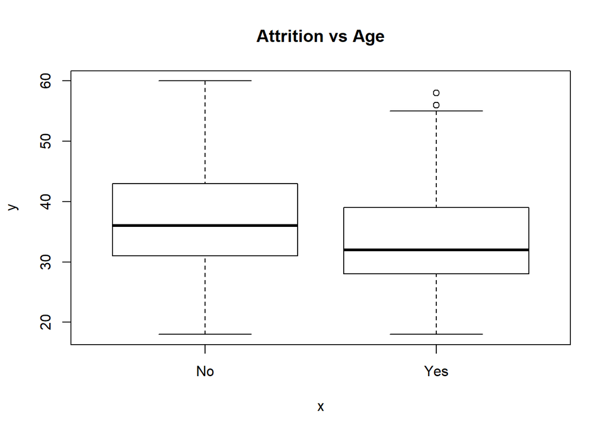

```r
plot(x=data$Attrition, y=data$Age, main ="Attrition vs Age")
```

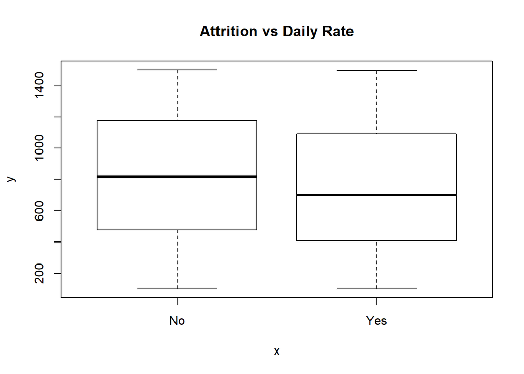

```r
plot(x=data$Attrition, y=data$DailyRate, main ="Attrition vs Daily Rate")
```

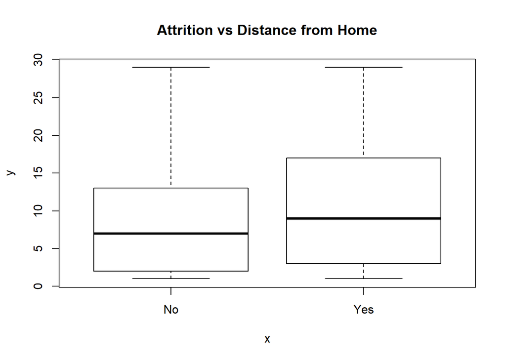

```r
plot(x=data$Attrition, y=data$DistanceFromHome, main ="Attrition vs Distance from Home")
```

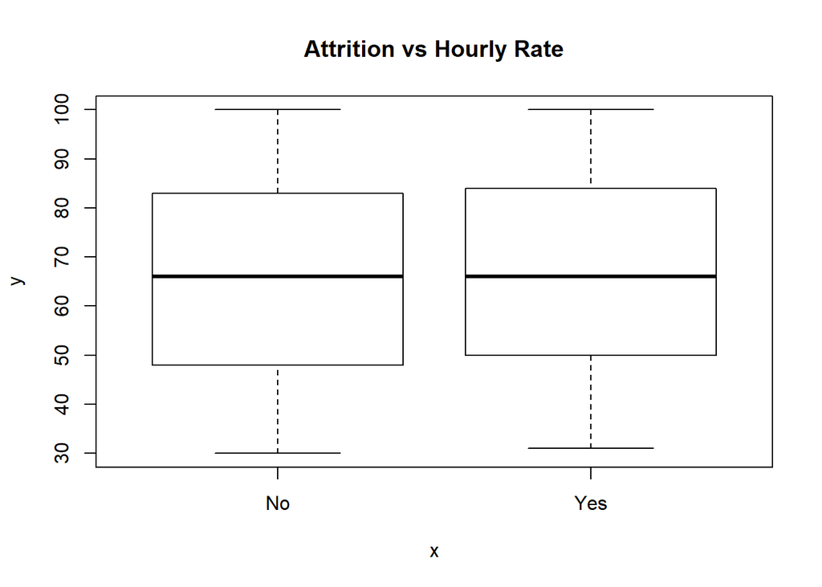

```r
plot(x=data$Attrition, y=data$HourlyRate, main = "Attrition vs Hourly Rate")
```

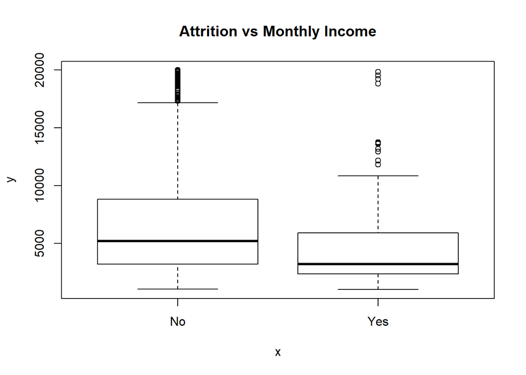

```r
plot(x=data$Attrition, y=data$MonthlyIncome, main="Attrition vs Monthly Income")
```

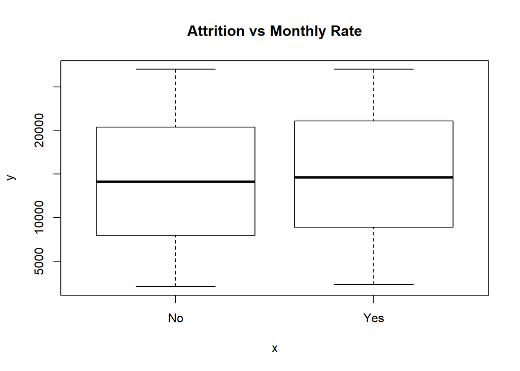

```r
plot(x=data$Attrition, y=data$MonthlyRate, main="Attrition vs Monthly Rate")
```

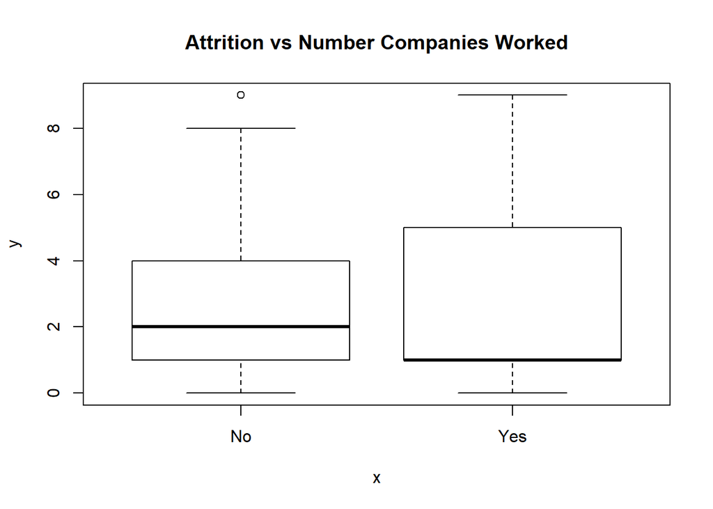

```r
plot(x=data$Attrition, y=data$NumCompaniesWorked, main="Attrition vs Number Companies Worked")
```

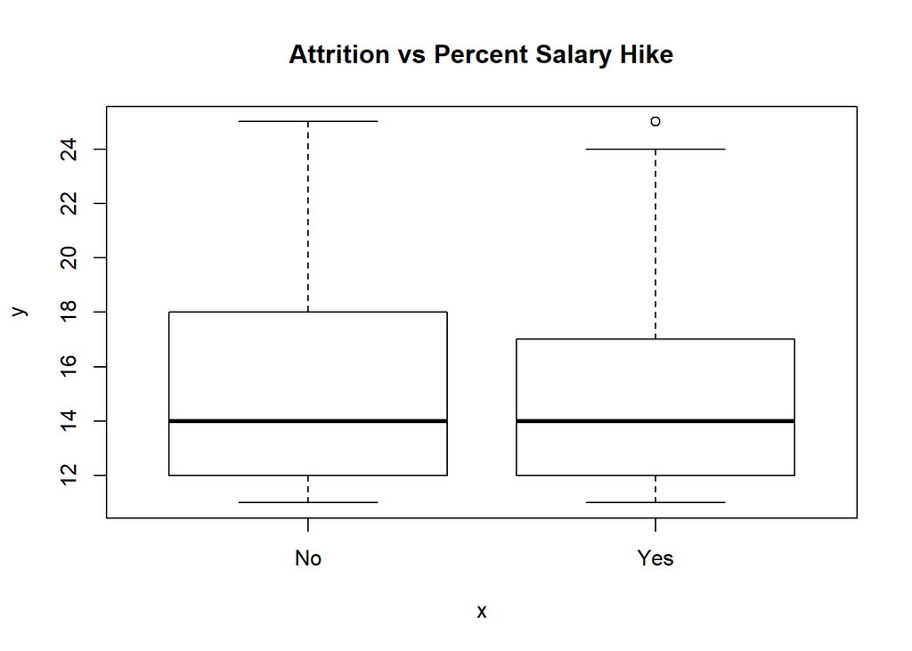

```r
plot(x=data$Attrition, y=data$PercentSalaryHike, main="Attrition vs Percent Salary Hike")
```

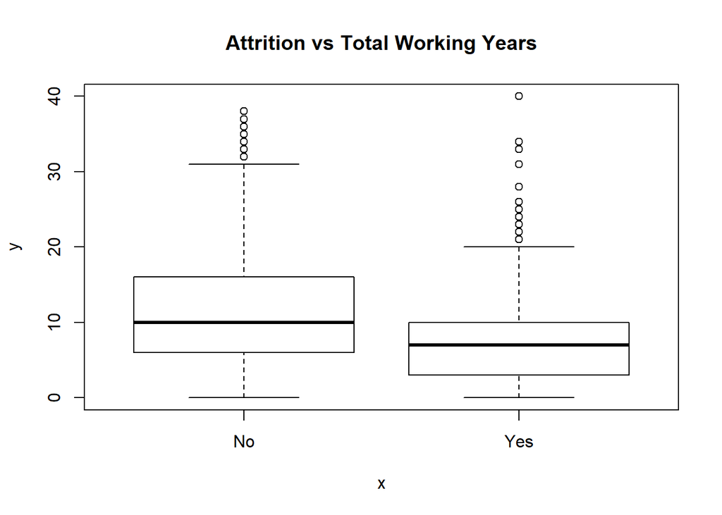

```r
plot(x=data$Attrition, y=data$TotalWorkingYears, main="Attrition vs Total Working Years")
```

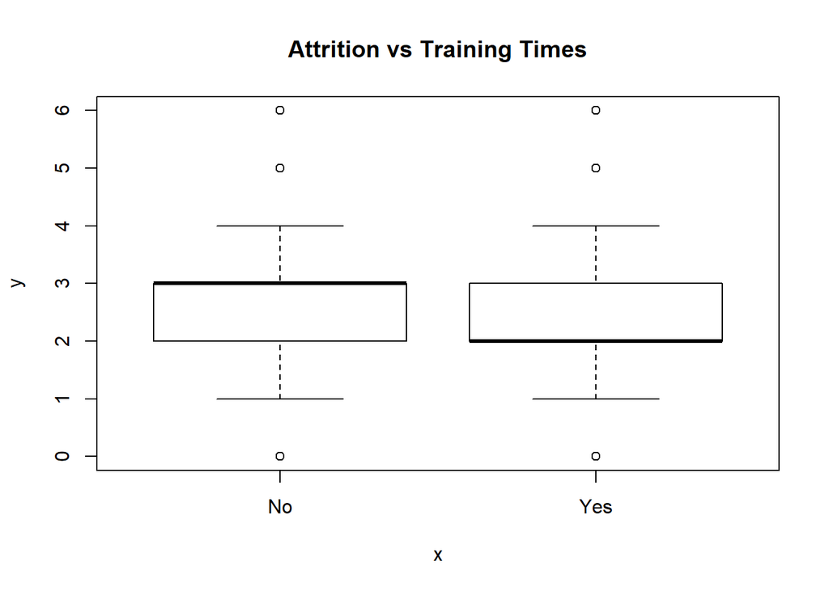

```r
plot(x=data$Attrition, y=data$TrainingTimesLastYear, main="Attrition vs Training Times")
```

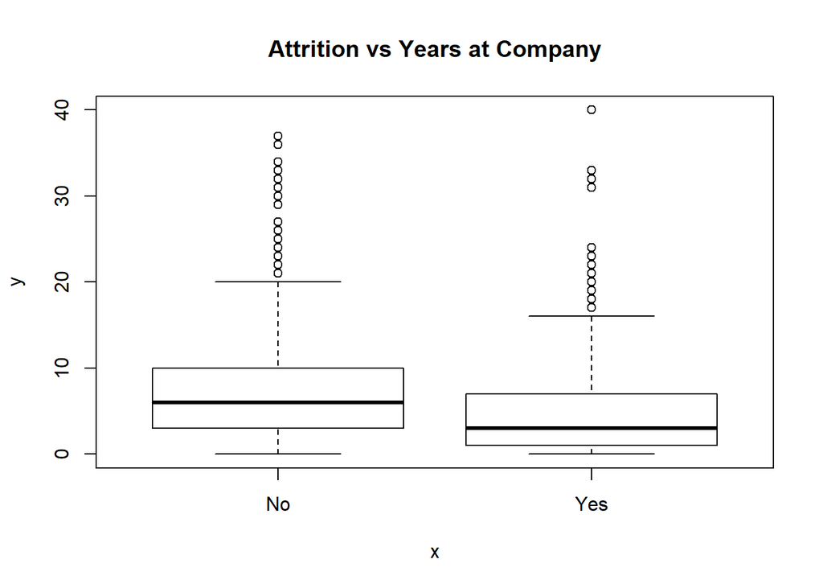

```r
plot(x=data$Attrition, y=data$YearsAtCompany, main="Attrition vs Years at Company")
```

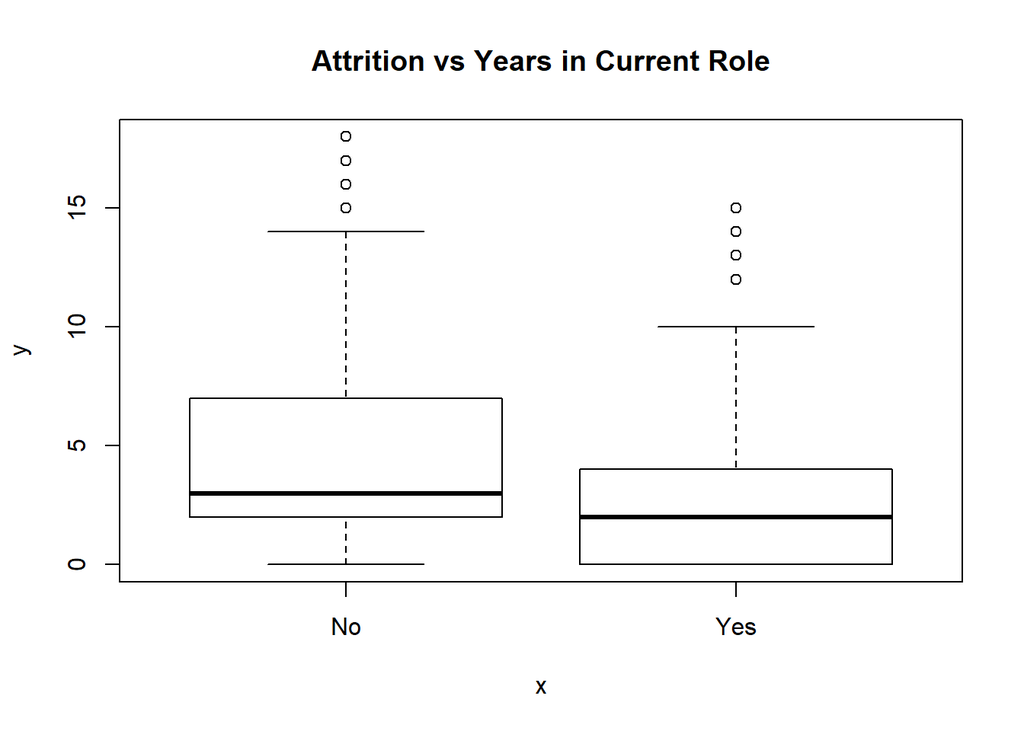

```r
plot(x=data$Attrition, y=data$YearsInCurrentRole, main="Attrition vs Years in Current Role")
```

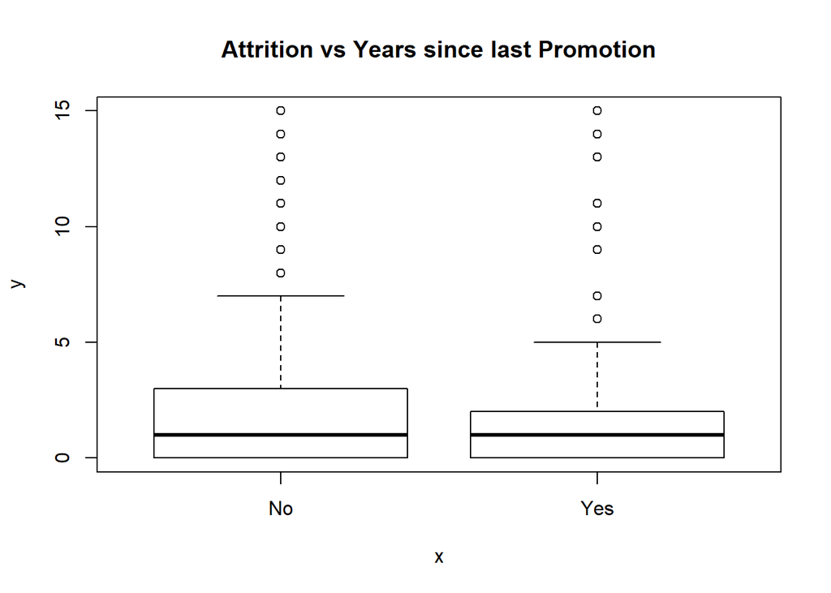

```r
plot(x=data$Attrition, y=data$YearsSinceLastPromotion, main="Attrition vs Years since last Promotion")
```

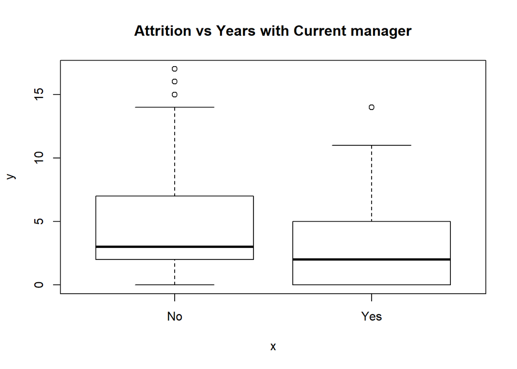

```r
plot(x=data$Attrition, y=data$YearsWithCurrManager, main="Attrition vs Years with Current manager")
```

Categorical Variables vs Dependent Variable

```r
plot_travel = table(data$Attrition, data$BusinessTravel)
prop.table(plot_travel, 2)
```

```
##
##       Non-Travel Travel_Frequently Travel_Rarely
##   No   0.9200000         0.7509025     0.8504314
##   Yes  0.0800000         0.2490975     0.1495686
```

```r
#
plot_dept = table(data$Attrition, data$Department)
prop.table(plot_dept, 2)
```

```
##
##       Human Resources Research & Development     Sales
##   No        0.8095238              0.8616025 0.7937220
##   Yes       0.1904762              0.1383975 0.2062780
```

```r
#
plot_education = table(data$Attrition, data$Education)
Names = c("Below College", "College", "bachelor", "Masters", "PHD")
colnames(plot_education) <- Names
prop.table(plot_education, 2)
```

```
##
##       Below College   College  bachelor   Masters       PHD
##   No      0.8176471 0.8439716 0.8269231 0.8542714 0.8958333
##   Yes     0.1823529 0.1560284 0.1730769 0.1457286 0.1041667
```

```r
#
plot_field = table(data$Attrition, data$EducationField)
prop.table(plot_field, 2)
```

```
##
##       Human Resources Life Sciences Marketing   Medical     Other
##   No        0.7407407     0.8531353 0.7798742 0.8642241 0.8658537
##   Yes       0.2592593     0.1468647 0.2201258 0.1357759 0.1341463
##
##       Technical Degree
##   No         0.7575758
##   Yes        0.2424242
```

```r
#
plot_envsat = table(data$Attrition, data$EnvironmentSatisfaction)
Names = c("Low", "Medium", "High", "Very High")
colnames(plot_envsat) <- Names
prop.table(plot_envsat, 2)
```

```
##
##             Low    Medium      High Very High
##   No  0.7464789 0.8501742 0.8631347 0.8654709
##   Yes 0.2535211 0.1498258 0.1368653 0.1345291
```

```r
#
plot_gender = table(data$Attrition, data$Gender)
prop.table(plot_gender, 2)
```

```
##
##          Female      Male
##   No  0.8520408 0.8299320
##   Yes 0.1479592 0.1700680
```

```r
#
plot_involvement = table(data$Attrition, data$JobInvolvement)
Names = c("Low", "Medium", "High", "Very High")
colnames(plot_involvement) <- Names
prop.table(plot_involvement, 2)
```

```
##
##              Low     Medium       High  Very High
##   No  0.66265060 0.81066667 0.85599078 0.90972222
##   Yes 0.33734940 0.18933333 0.14400922 0.09027778
```

```r
#
plot_joblevel = table(data$Attrition, data$JobLevel)
Names = c("Lowest", "Low", "Medium", "High", "Highest")
colnames(plot_joblevel) <- Names
prop.table(plot_joblevel, 2)
```

```
##
##           Lowest        Low     Medium       High    Highest
##   No  0.73664825 0.90262172 0.85321101 0.95283019 0.92753623
##   Yes 0.26335175 0.09737828 0.14678899 0.04716981 0.07246377
```

```r
#
plot_jobrole = table(data$Attrition, data$JobRole)
prop.table(plot_jobrole, 2)
```

```
##
##       Healthcare Representative Human Resources Laboratory Technician
##   No                 0.93129771      0.76923077            0.76061776
##   Yes                0.06870229      0.23076923            0.23938224
##
##          Manager Manufacturing Director Research Director Research Scientist
##   No  0.95098039             0.93103448        0.97500000         0.83904110
##   Yes 0.04901961             0.06896552        0.02500000         0.16095890
##
##       Sales Executive Sales Representative
##   No       0.82515337           0.60240964
##   Yes      0.17484663           0.39759036
```

```r
#
plot_jobsat = table(data$Attrition, data$JobSatisfaction)
Names = c("Low", "Medium", "High", "Very High")
colnames(plot_jobsat) <- Names
prop.table(plot_jobsat, 2)
```

```
##
##             Low    Medium      High Very High
##   No  0.7716263 0.8357143 0.8348416 0.8867102
##   Yes 0.2283737 0.1642857 0.1651584 0.1132898
```

```r
#
plot_maritial = table(data$Attrition, data$MaritalStatus)
prop.table(plot_maritial, 2)
```

```
##
##        Divorced   Married    Single
##   No  0.8990826 0.8751857 0.7446809
##   Yes 0.1009174 0.1248143 0.2553191
```

```r
#
plot_overtime = table(data$Attrition, data$OverTime)
prop.table(plot_overtime, 2)
```

```
##
##              No       Yes
##   No  0.8956357 0.6947115
##   Yes 0.1043643 0.3052885
```

```r
#
plot_rating = table(data$Attrition, data$PerformanceRating)
Names = c("Excellent", "Outstanding")
colnames(plot_rating) <- Names
prop.table(plot_rating, 2)
```

```
##
##       Excellent Outstanding
##   No  0.8392283   0.8362832
##   Yes 0.1607717   0.1637168
```

```r
#
plot_relsat = table(data$Attrition, data$RelationshipSatisfaction)
Names = c("Low", "Medium", "High", "Very High")
colnames(plot_relsat) <- Names
prop.table(plot_relsat, 2)
```

```
##
##             Low    Medium      High Very High
##   No  0.7934783 0.8514851 0.8453159 0.8518519
##   Yes 0.2065217 0.1485149 0.1546841 0.1481481
```

```r
#
plot_options = table(data$Attrition, data$StockOptionLevel)
Names = c("None", "Low", "Medium", "High")
colnames(plot_options) <- Names
prop.table(plot_options, 2)
```

```
##
##             None        Low     Medium       High
##   No  0.75594295 0.90604027 0.92405063 0.82352941
##   Yes 0.24405705 0.09395973 0.07594937 0.17647059
```

```r
#
plot_worklife = table(data$Attrition, data$WorkLifeBalance)
Names = c("Low", "Medium", "High", "Very High")
colnames(plot_worklife) <- Names
prop.table(plot_worklife, 2)
```

```
##
##             Low    Medium      High Very High
##   No  0.6875000 0.8313953 0.8577828 0.8235294
##   Yes 0.3125000 0.1686047 0.1422172 0.1764706
```

```r
#
```

Results

Age - young employees have a higher attrition rate

Daily rate - no significant difference

Department - Sales and Human Resources have higher attrition rates than R&D

Distance from Home - employees who commute farther have higher attrition

Education - employees with lower education (no college, college, etc.) are somewhat more likely to quit

Employee Count - N/A (variable will be removed)

Employee Number - N/A (variable will be removed)

Environment Satisfaction - employees with low environment satisfaction much more likley to quit

Gender - male and femal employees quit at similar rates

Hourly rate - no significant difference

Job Involvement - employees with low job involvement much more likly to quit

Job Level - employees at low levels more likley to quit

Job Role - employees in Sales and Human Resources more likly to quit

Job satisfaction - employees with low job satisfaction levels more likley to quit

Maritial Status - single employees more liklely to quit

Monthly Income - employees with lower incomes more likly to quit

Monthly rate - no significant difference

Number of companies worked - employyes who have worked for few companies more likley to leave

Over 18 - N/A (variable will be removed)

Overtime - employees who get overtime much more likley to quit

Percent salary hike - no significant differenc between employees who stay or leave

Performance rating - no significant difference between emploees who stay and leave.

Relationship Satisfaction - employees with very low relationship satisfaction more likley to quit

Standard hours - N/A (variable will be removed)

Stock Options - employees with no options more likley to quit

Total working years - employees with fewer working years more likley to quit

Training times - people with very little training more likley to quit

Worklife balance - employees with low worklife balance much more likley to quit

Years at company - employees with fewer years more likley to quit

Years in current role - employyes most likley to leave in first few years in role

Years since last promotion - no significant difference between employees who stay or leave

Years with current manager - employees most likley to quit first year

### Correlation

analyze correlation of numerical variables

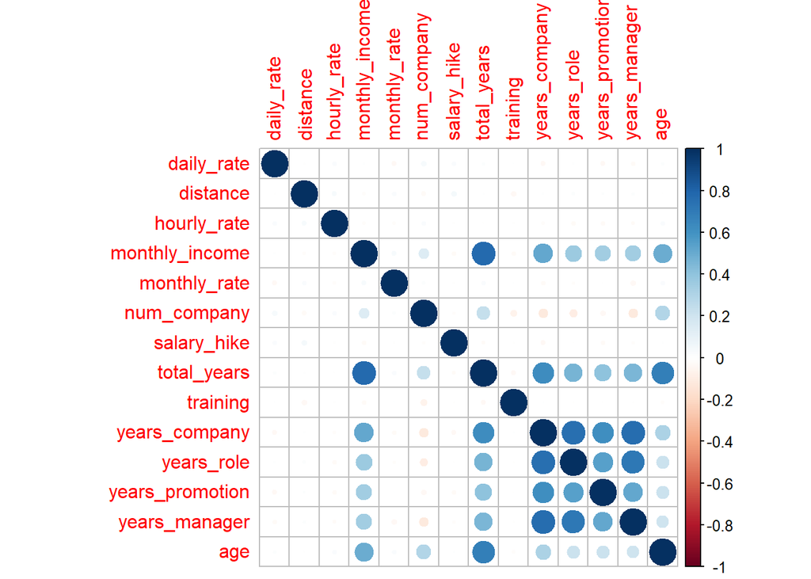

```r
# combine numeric variables into a new dataframe
df1 <- cbind(data$DailyRate, data$DistanceFromHome, data$HourlyRate, data$MonthlyIncome, data$MonthlyRate, data$NumCompaniesWorked, data$PercentSalaryHike, data$TotalWorkingYears, data$TrainingTimesLastYear, data$YearsAtCompany, data$YearsInCurrentRole, data$YearsSinceLastPromotion, data$YearsWithCurrManager, data$Age)
dfnum <- data.frame(df1)
names <- c("daily_rate", "distance", "hourly_rate", "monthly_income", "monthly_rate", "num_company", "salary_hike", "total_years", "training", "years_company", "years_role", "years_promotion", "years_manager", "age")
colnames(dfnum) <- names
# calculate correlation
dfnum.cor = cor(dfnum)
# install .packages("corrplot")
library(corrplot)
corrplot(dfnum.cor)
```

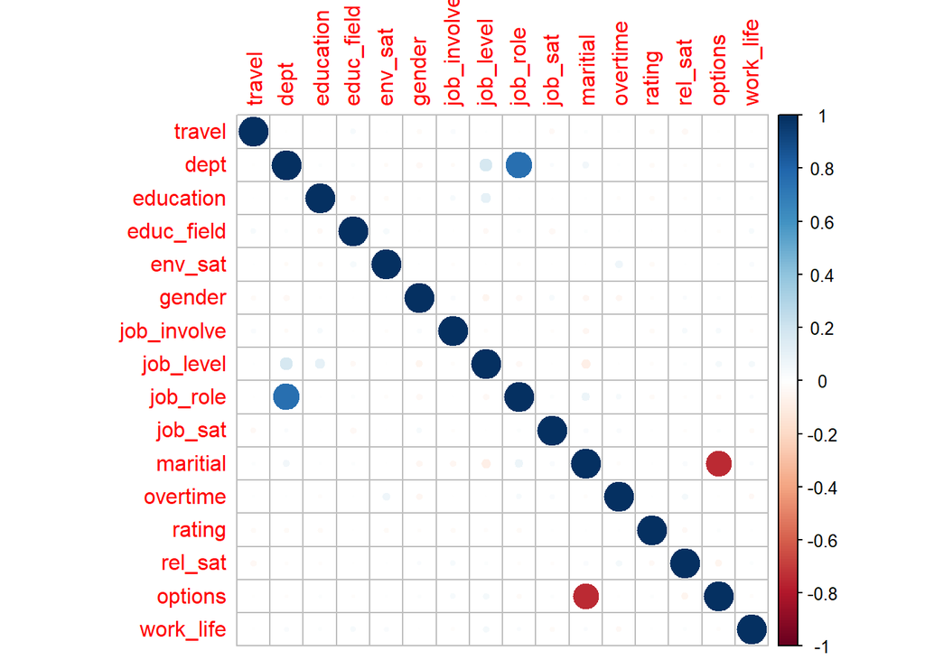

```r
# combine categorical varibles into a new dataframe
df2 <- cbind(data$BusinessTravel, data$Department, data$Education, data$EducationField, data$EnvironmentSatisfaction, data$Gender, data$JobInvolvement, data$JobLevel, data$JobRole, data$JobSatisfaction, data$MaritalStatus, data$OverTime, data$PerformanceRating, data$RelationshipSatisfaction, data$StockOptionLevel, data$WorkLifeBalance)
names1 <- c("travel", "dept", "education", "educ_field", "env_sat", "gender", "job_involve", "job_level", "job_role", "job_sat", "maritial", "overtime", "rating", "rel_sat", "options", "work_life")
#
dfcat <- data.frame(df2)
colnames(dfcat) <- names1
# calculate correlation
dfcat.cor = cor(dfcat, method = "spearman")
library(corrplot)
corrplot(dfcat.cor)
```

Results

An analysis of corr and corrplot shows that a number of variables seem to have strong (corr 0.60 - 0.79) or very strong (corr > 0.80) correlations:

Numerical Variables - monthly income vs total working years (corr = 0.77) - age vs total working years(corr = 0.68) - years at company vs total working years (corr =0.63) - years at company vs years in current role (corr = 0.76) - years with current manager vs years at company (corr =0.77) - years with current manager vs years in current role (corr=0.77) - years at company vs years since last promotion (corr =0.62)

# Data Preparation

## Remove Redundant Variables

```r
# remove 4 redundant variables identified as redundant in EDA
att <- data[,-c(8,9,21,26)]
```

## Multi-Collinearity

```r
#convert factors to numeric
att$Leave <- ifelse(att$Attrition == "Yes",1,0)
att$BusinessTravel <-as.numeric(att$BusinessTravel)
att$Department <- as.numeric(att$Department)
att$EducationField <- as.numeric(att$EducationField)
att$Gender <- as.numeric(att$Gender)
att$JobRole <- as.numeric(att$JobRole)
att$MaritalStatus <-as.numeric(att$MaritalStatus)
att$OverTime <-as.numeric(att$OverTime)
# str(att)
```

# Test for multi-collinearity using Farrar-Gauber Test

```r
# install.packages("mctest")
library(mctest)
Y <- att$Leave
X <-att[,-c(1,32)]  #remove dependent variable
omcdiag(X,Y)
```

```
##
## Call:
## omcdiag(x = X, y = Y)
##
##
## Overall Multicollinearity Diagnostics
##
##                        MC Results detection
## Determinant |X'X|:         0.0001         1
## Farrar Chi-Square:     13932.0467         1
## Red Indicator:             0.1548         0
## Sum of Lambda Inverse:    70.6887         0
## Theil's Method:            2.9790         1
## Condition Number:         99.8255         1
##
## 1 --> COLLINEARITY is detected by the test
## 0 --> COLLINEARITY is not detected by the test
```

Test original dataset variables for multi-collinearity

```r
df <- att[,-1]
output <- lm(Leave ~., data = df)
# install.packages("car")
library(car)
car::vif(output)
```

```
##           BusinessTravel                DailyRate               Department
##                 1.016413                 1.023990                 1.942150
##         DistanceFromHome                Education           EducationField
##                 1.017135                 1.063531                 1.016236
##  EnvironmentSatisfaction                   Gender               HourlyRate
##                 1.017516                 1.019383                 1.021142
##           JobInvolvement                 JobLevel                  JobRole
##                 1.020804                11.821396                 1.894260
##          JobSatisfaction            MaritalStatus            MonthlyIncome
##                 1.020727                 1.840999                11.052627
##              MonthlyRate       NumCompaniesWorked                 OverTime
##                 1.015602                 1.261957                 1.028587
##        PercentSalaryHike        PerformanceRating RelationshipSatisfaction
##                 2.521576                 2.519366                 1.020852
##         StockOptionLevel        TotalWorkingYears    TrainingTimesLastYear
##                 1.819542                 4.824448                 1.023713
##          WorkLifeBalance           YearsAtCompany       YearsInCurrentRole
##                 1.018516                 4.601972                 2.728267
##  YearsSinceLastPromotion     YearsWithCurrManager                      Age
##                 1.678879                 2.782899                 2.054172
```

Revise dataset to exlude highly correlated variables This was done in multiple cycles by adding / dropping variables and reviewing vif results Final result was that five variables were removed

```r
df1 <- df[,-c(15, 20, 23, 26, 29)]
output <- lm(Leave ~., data = df1)
library(car)
car::vif(output)
```

```
##           BusinessTravel                DailyRate               Department
##                 1.012430                 1.018545                 1.887875
##         DistanceFromHome                Education           EducationField
##                 1.012102                 1.061782                 1.015220
##  EnvironmentSatisfaction                   Gender               HourlyRate
##                 1.015666                 1.018248                 1.019422
##           JobInvolvement                 JobLevel                  JobRole
##                 1.015066                 1.632531                 1.880136
##          JobSatisfaction            MaritalStatus              MonthlyRate
##                 1.018207                 1.837979                 1.012115
##       NumCompaniesWorked                 OverTime        PercentSalaryHike
##                 1.158506                 1.026057                 1.009869
## RelationshipSatisfaction         StockOptionLevel    TrainingTimesLastYear
##                 1.018685                 1.813893                 1.022260
##          WorkLifeBalance       YearsInCurrentRole  YearsSinceLastPromotion
##                 1.014874                 1.573586                 1.496966
##                      Age
##                 1.535321
```

Results - four variables identified as redundant in EDA removed - five variables removed due to multi-collinearity analysis - Final analysis of vif shows multi-collinearity greatly reduced (max value < 2)

Variables removed during Multi-collinearity: - monthly income - performance Rating - monthly income - total working years - years at company - years with current manager

# Model Building

Prepare dataset for logistic regression

```r
mydata <- data[,-c(8,9,21,26)] # remove EDA redundant variables
mydata$Leave <- ifelse(mydata$Attrition == "Yes",1,0)
# mydata1 <- mydata[,-1]
mydata1 <- mydata[,-c(16,21,24,27,30)] #remove multi-collinearity variables
mydata2 <- mydata1
mydata2$Education <- as.factor(mydata2$Education)
mydata2$EnvironmentSatisfaction <- as.factor(mydata2$EnvironmentSatisfaction)
mydata2$JobInvolvement <- as.factor(mydata2$JobInvolvement)
mydata2$JobLevel <- as.factor(mydata2$JobLevel)
mydata2$JobSatisfaction <- as.factor(mydata2$JobSatisfaction)
mydata2$RelationshipSatisfaction <- as.factor(mydata2$RelationshipSatisfaction)
mydata2$StockOptionLevel <- as.factor(mydata2$StockOptionLevel)
mydata2$WorkLifeBalance <- as.factor(mydata2$WorkLifeBalance)
```

```r
# train_index <- sample(1:nrow(mydata2), .7*nrow(mydata2))
# traindata <- mydata2[train_index,]
# testdata <- mydata2[-train_index,]
```

## Logistic reqression

```r
set.seed(2020)
mydata_GLM <- mydata2[,-1]
train_index <- sample(1:nrow(mydata_GLM), .7*nrow(mydata_GLM))
traindata <- mydata_GLM[train_index,]
testdata <- mydata_GLM[-train_index,]
model_GLM <- glm(Leave ~. , family = "binomial", data = traindata)
summary(model_GLM)
```

```
##
## Call:
## glm(formula = Leave ~ ., family = "binomial", data = traindata)
##
## Deviance Residuals:
##     Min       1Q   Median       3Q      Max
## -1.8879  -0.4286  -0.1945  -0.0576   3.4888
##
## Coefficients:
##                                    Estimate Std. Error z value Pr(>|z|)
## (Intercept)                      -9.813e+00  5.324e+02  -0.018 0.985295
## BusinessTravelTravel_Frequently   1.571e+00  5.242e-01   2.997 0.002725 **
## BusinessTravelTravel_Rarely       7.105e-01  4.833e-01   1.470 0.141554
## DailyRate                        -4.915e-04  2.913e-04  -1.687 0.091536 .
## DepartmentResearch & Development  1.204e+01  5.324e+02   0.023 0.981957
## DepartmentSales                   1.287e+01  5.324e+02   0.024 0.980714
## DistanceFromHome                  7.257e-02  1.486e-02   4.882 1.05e-06 ***
## Education2                        6.851e-01  4.192e-01   1.634 0.102202
## Education3                        6.289e-01  3.739e-01   1.682 0.092567 .
## Education4                        2.507e-01  4.064e-01   0.617 0.537207
## Education5                        6.750e-01  7.254e-01   0.930 0.352134
## EducationFieldLife Sciences      -5.533e-01  1.272e+00  -0.435 0.663485
## EducationFieldMarketing           7.371e-02  1.321e+00   0.056 0.955489
## EducationFieldMedical            -2.169e-01  1.273e+00  -0.170 0.864726
## EducationFieldOther              -5.303e-01  1.353e+00  -0.392 0.695046
## EducationFieldTechnical Degree    1.155e+00  1.271e+00   0.909 0.363446
## EnvironmentSatisfaction2         -1.094e+00  3.510e-01  -3.117 0.001825 **
## EnvironmentSatisfaction3         -1.502e+00  3.407e-01  -4.409 1.04e-05 ***
## EnvironmentSatisfaction4         -1.505e+00  3.357e-01  -4.482 7.41e-06 ***
## GenderMale                        4.090e-01  2.373e-01   1.723 0.084831 .
## HourlyRate                        4.629e-03  5.804e-03   0.798 0.425138
## JobInvolvement2                  -1.262e+00  4.659e-01  -2.709 0.006746 **
## JobInvolvement3                  -1.645e+00  4.399e-01  -3.738 0.000185 ***
## JobInvolvement4                  -2.425e+00  6.063e-01  -3.999 6.36e-05 ***
## JobLevel2                        -1.514e+00  4.995e-01  -3.031 0.002434 **
## JobLevel3                        -3.864e-01  6.403e-01  -0.603 0.546228
## JobLevel4                        -1.479e+00  9.640e-01  -1.534 0.125083
## JobLevel5                         1.089e+00  1.567e+00   0.695 0.486947
## JobRoleHuman Resources            1.245e+01  5.324e+02   0.023 0.981346
## JobRoleLaboratory Technician      9.534e-01  6.661e-01   1.431 0.152371
```

[output cut: 23 more lines]

```
## WorkLifeBalance3                 -1.458e+00  4.550e-01  -3.204 0.001357 **
## WorkLifeBalance4                 -1.052e+00  5.474e-01  -1.922 0.054641 .
## YearsInCurrentRole               -1.870e-01  4.912e-02  -3.807 0.000140 ***
## YearsSinceLastPromotion           1.721e-01  5.025e-02   3.424 0.000617 ***
## Age                              -3.917e-02  1.600e-02  -2.448 0.014383 *
## ---
## Signif. codes:  0 '***' 0.001 '**' 0.01 '*' 0.05 '.' 0.1 ' ' 1
##
## (Dispersion parameter for binomial family taken to be 1)
##
##     Null deviance: 912.63  on 1028  degrees of freedom
## Residual deviance: 534.39  on  971  degrees of freedom
## AIC: 650.39
##
## Number of Fisher Scoring iterations: 14
```

Confusion Matrix

```r
pred_logistic <- predict(model_GLM, type = "response", newdata = testdata)
table(testdata$Leave, pred_logistic > .5)
```

```
##
##     FALSE TRUE
##   0   353   18
##   1    41   29
```

ROC curve

```r
# install.packages("ROCR")
library(ROCR)
glm_ROC <- pred_logistic
pred_GLM <- prediction(glm_ROC, testdata$Leave)
auc_GLM <- performance(pred_GLM, "auc")
auc_GLM <- round(as.numeric(auc_GLM@y.values),2)
auc_GLM
```

```
## [1] 0.84
```

```r
# perf_GLM <- performance(pred_GLM, "tpr", "fpr")
# plot(perf_GLM, main = "ROC curve for Logistic Regression")
```

## Decision Tree Model

```r
set.seed(2020)
mydata_tree <- mydata2 [,-27]
train_index <- sample(1:nrow(mydata_tree), .7*nrow(mydata_tree))
traindata <- mydata_tree[train_index,]
testdata <- mydata_tree[-train_index,]
# install.packages("rpart")
library(rpart)
model_tree <- rpart(Attrition ~., data = traindata, method="class")
summary(model_tree)
```

```
## Call:
## rpart(formula = Attrition ~ ., data = traindata, method = "class")
##   n= 1029
##
##           CP nsplit rel error   xerror       xstd
## 1 0.03992016      0 1.0000000 1.000000 0.07082518
## 2 0.03293413      3 0.8802395 1.029940 0.07166886
## 3 0.01796407      5 0.8143713 0.988024 0.07048143
## 4 0.01000000      9 0.7425150 1.023952 0.07150189
##
## Variable importance
##                 JobRole                OverTime                JobLevel
##                      22                      20                      15
##                     Age          JobInvolvement              Department
##                      10                       7                       5
##        StockOptionLevel        DistanceFromHome      NumCompaniesWorked
##                       4                       3                       3
##          EducationField      YearsInCurrentRole           MaritalStatus
##                       2                       2                       2
##               DailyRate              HourlyRate EnvironmentSatisfaction
##                       2                       1                       1
##               Education
##                       1
##
## Node number 1: 1029 observations,    complexity param=0.03992016
##   predicted class=No   expected loss=0.1622935  P(node) =1
##     class counts:   862   167
##    probabilities: 0.838 0.162
##   left son=2 (738 obs) right son=3 (291 obs)
##   Primary splits:
##       OverTime           splits as  LR,        improve=21.870250, (0 missing)
##       JobLevel           splits as  RLRLL,     improve=10.760180, (0 missing)
##       JobRole            splits as  LLRLLLLLR, improve=10.693650, (0 missing)
##       StockOptionLevel   splits as  RLLR,      improve= 9.932784, (0 missing)
##       YearsInCurrentRole < 0.5   to the right, improve= 7.953623, (0 missing)
##
## Node number 2: 738 observations
##   predicted class=No   expected loss=0.09756098  P(node) =0.7172012
##     class counts:   666    72
##    probabilities: 0.902 0.098
```

[output cut: 166 more lines]

```
##
## Node number 53: 9 observations
##   predicted class=Yes  expected loss=0.3333333  P(node) =0.008746356
##     class counts:     3     6
##    probabilities: 0.333 0.667
##
## Node number 60: 11 observations
##   predicted class=No   expected loss=0  P(node) =0.01068999
##     class counts:    11     0
##    probabilities: 1.000 0.000
##
## Node number 61: 14 observations
##   predicted class=Yes  expected loss=0.2857143  P(node) =0.01360544
##     class counts:     4    10
##    probabilities: 0.286 0.714
```

Confusion Matrix

```r
pred_tree <- predict(model_tree, type = "class", newdata = testdata)
table(testdata$Attrition, pred_tree)
```

```
##      pred_tree
##        No Yes
##   No  353  18
##   Yes  55  15
```

ROC Curve

```r
# install.packages("ROCR")
library(ROCR)
DT_ROC <- predict(model_tree, testdata)
pred_DT <- prediction(DT_ROC[,2], testdata$Attrition)
auc_tree <- performance(pred_DT, "auc")
auc_tree <- round(as.numeric(auc_tree@y.values),2)
auc_tree
```

```
## [1] 0.62
```

Initial Results Logistic Regresion: accuracy = 86%, AUC = 0.84 Decision Tree: accuracy = 83%, AUC =0.62

Logistic Regression scores better on both accuracy and AUC Initial results suggest that Logistic Regression is the better classifier model

Logistic Regression Confusion Matrix TN = 89% FN = 10% FP = 38% TP = 61% Accuracy = 86%

Logistic regression does a better job of predicting who will stay vs who will leave This may be due to the unbalanced depenednt varaible (attrion = 16%, non-attrition = 84%)